# Xenium5k_custom_gene_test

Sifan Zhang

2024-12-02

**This script is for testing how 100 add-on genes looks like with Xenium 5k panel** Will substrate genes from public dataset, so the results really depends on what dataset you are using

# Prepare r packages

```r
library(SeuratObject)
library(Seurat)
library(Matrix)
library(ggplot2)
library(cowplot)
library(dplyr)
library(harmony)
```

# Set up R environment

```r
knitr::opts_chunk$set(echo = TRUE, message=F, warning=F)

# sets the directory of all chunks to the directory of this script
knitr::opts_knit$set(root.dir = "M:/SifanZ/OneDrive - Westmead Institute for Medical Research/Data/scRNA_LN/GSE254435/Xenium5k")

theme_set(theme_classic())
set.seed(1337)
```

# Load integrated public dataset

Loading and integration need to be done prior to this workflow

```r
LN <- readRDS("M:/SifanZ/OneDrive - Westmead Institute for Medical Research/Data/scRNA_LN/GSE254435/Xenium5k/LN_annotated.rds")
LN
```

```
## An object of class Seurat
## 22198 features across 7657 samples within 1 assay
## Active assay: RNA (22198 features, 2000 variable features)
##  3 layers present: data, counts, scale.data
##  4 dimensional reductions calculated: pca, umap.unintegrated, harmony, umap
```

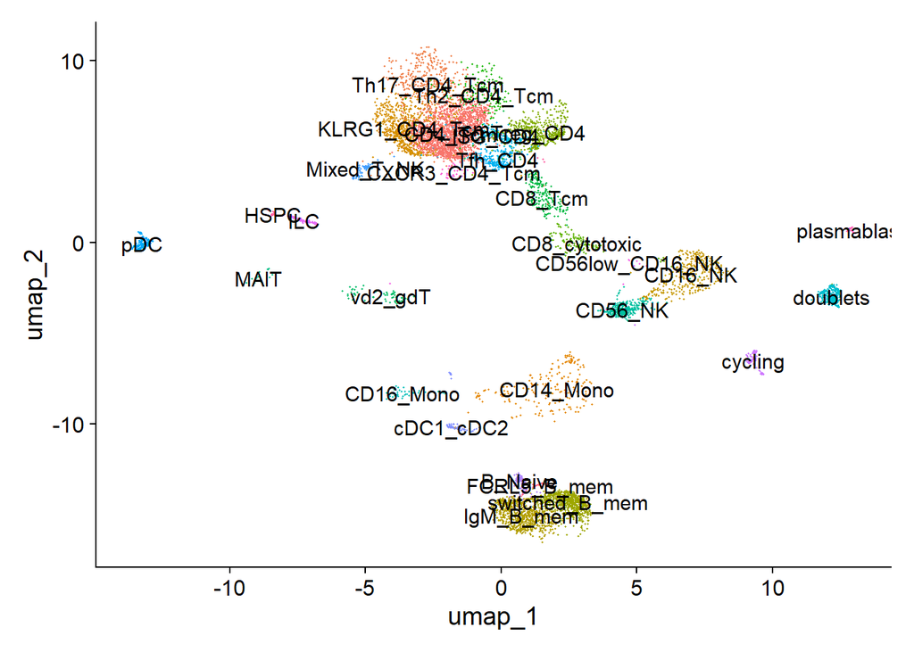

```r
DimPlot(LN,reduction = "umap", label=T)+NoLegend()
```

# Calculate overlap genes between 5101 gene panel and this dataset You need to determine final add-on gene list using [Xenium panel designer](https://cloud.10xgenomics.com/xenium-panel-designer)

```r
xenium5k <- read.csv("XeniumPrimeHuman5Kpan_tissue_pathways_metadata.csv")
head(xenium5k)
```

```
##   gene_name         gene_id num_codewords num_probesets
## 1     A2ML1 ENSG00000166535             2             2
## 2      AAMP ENSG00000127837             3             3
## 3      AAR2 ENSG00000131043             3             3
## 4    AARSD1 ENSG00000266967             3             3
## 5      ABAT ENSG00000183044             3             3
## 6     ABCA1 ENSG00000165029             3             3
##                                                                                                  full_name
## 1 Alpha-2-macroglobulin-like protein 1 (C3 and PZP-like alpha-2-macroglobulin domain-containing protein 9)
## 2                                                                  Angio-associated migratory cell protein
## 3                                                      Protein AAR2 homolog (AAR2 splicing factor homolog)
## 4                  Alanyl-tRNA editing protein Aarsd1 (Alanyl-tRNA synthetase domain-containing protein 1)
## 5                                                          4-aminobutyrate aminotransferase, mitochondrial
## 6                                                                   Phospholipid-transporting ATPase ABCA1
##                  location
## 1                Secreted
## 2 Cell membrane;Cytoplasm
## 3
## 4               Cytoplasm
## 5    Mitochondrion matrix
## 6           Cell membrane
##                                                                                                                                                                                                                                                                                                          …
## 1                                                                                                                                                                                                                                   stem cell;basal cell;epithelial cell of stratum germinativum of esoph…
## 2                                                                                                                                                                                                                                                                                                        …
## 3
## 4
## 5
## 6 hepatocyte;periportal region hepatocyte;midzonal region hepatocyte;centrilobular region hepatocyte;alternatively activated macrophage;Kupffer cell;immature innate lymphoid cell;medium spiny neuron;connective tissue cell;fibroblast;hepatic stellate cell;fibroblast of lung;mesothelial fibroblast;…
##   cellchat_pathway
## 1
## 2
## 3
## 4
## 5
## 6             ApoA
```

```r
length(rownames(xenium5k))
```

```
## [1] 5001
```

```r
addgenes <- read.csv("gene_list.csv")
head(addgenes)
```

```
##     Gene      Ensembl.ID Probesets
## 1   IRF2 ENSG00000168310         5
## 2  CASP4 ENSG00000196954         5
## 3  CASP5 ENSG00000137757         4
## 4  GSDMD ENSG00000104518         4
## 5  HMGB1 ENSG00000189403         4
## 6 TRIM69 ENSG00000185880         5
```

```r
length(rownames(addgenes))
```

```
## [1] 100
```

```r
allgenes<-LN@assays$RNA@meta.data$ensembl

xenium5kgenes<-xenium5k$gene_id
addgenes<- addgenes$Ensembl.ID
custom_genes <- c(xenium5kgenes, addgenes)
length(custom_genes)
```

```
## [1] 5101
```

```r
commongenes<-intersect(allgenes,custom_genes)
length(commongenes)
```

```
## [1] 4204
```

```r
subset_meta.data<-LN@assays$RNA@meta.data %>% filter(ensembl %in% commongenes)
LN_5k <- subset(LN, features = subset_meta.data$geneID)
length(rownames(LN_5k))
```

```
## [1] 4204
```

```r
LN_5k
```

```
## An object of class Seurat
## 4204 features across 7657 samples within 1 assay
## Active assay: RNA (4204 features, 727 variable features)
##  3 layers present: data, counts, scale.data
##  4 dimensional reductions calculated: pca, umap.unintegrated, harmony, umap
```

```r
saveRDS(LN_5k, "LN_4204_genes.rds")
```

**NOTE:** from the results you can see that not all genes are overlapped, which means some genes in 5k panel are not found in the public dataset, this could due to QC steps which excluded some low-quality cells. In Xenium panel designer this means some genes are not found in your dataset, therefore can’t design probes. In order to fix this, you can upload single, pre-QC dataset, which contains all genes in there.

# Re-do dimentional reduction using 4204 genes

Integration using Seurat v5 can be found in seurat5_integration

```r
LN_5k <- readRDS("LN_4204_genes.rds")
DefaultAssay(LN_5k)<-"RNA"

LN_5k[["RNA"]] <- split(LN_5k[["RNA"]], f = LN_5k$donor)
LN_5k <- NormalizeData(LN_5k,verbose=F)
LN_5k <- FindVariableFeatures(LN_5k,verbose=F)
LN_5k <- ScaleData(LN_5k,verbose=F)
LN_5k <- RunPCA(LN_5k,verbose=F)

# checking unintegrated analysis
LN_5k <- FindNeighbors(LN_5k, dims = 1:45, reduction = "pca",verbose=F)
LN_5k <- FindClusters(LN_5k, resolution = 1.2, cluster.name = "unintegrated_clusters",verbose=F)
LN_5k <- RunUMAP(LN_5k, dims = 1:45, reduction = "pca", reduction.name = "umap.5k.unintegrated",verbose=F)

#integrating data
LN_5k <- IntegrateLayers(object = LN_5k, method = HarmonyIntegration, orig.reduction = "pca", new.reduction = "harmony.5K", verbose = T)
LN_5k[["RNA"]] <- JoinLayers(LN_5k[["RNA"]])

LN_5k <- FindNeighbors(LN_5k, reduction = "harmony.5K", dims = 1:45,verbose=F)
LN_5k <- FindClusters(LN_5k, resolution = 1.2,verbose=F)
LN_5k <- RunUMAP(LN_5k, dims = 1:45, reduction = "harmony.5K",reduction.name = "umap.5k.integrated",verbose=F)

LN_5k
```

```
## An object of class Seurat
## 4204 features across 7657 samples within 1 assay
## Active assay: RNA (4204 features, 2000 variable features)
##  3 layers present: data, counts, scale.data
##  7 dimensional reductions calculated: pca, umap.unintegrated, harmony, umap, umap.5k.unintegrated, harmony.5K, umap.5k.integrated
```

```r
saveRDS(LN_5k,"LN_5k_new_integration.rds")
```

# Comparison between unintegrated vs. integrated

```r
LN_5k <- readRDS("LN_5k_new_integration.rds")
LN_5k
```

```
## An object of class Seurat
## 4204 features across 7657 samples within 1 assay
## Active assay: RNA (4204 features, 2000 variable features)
##  3 layers present: data, counts, scale.data
##  7 dimensional reductions calculated: pca, umap.unintegrated, harmony, umap, umap.5k.unintegrated, harmony.5K, umap.5k.integrated
```

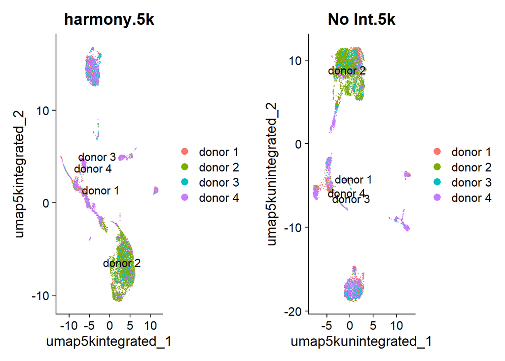

```r
plot_grid(
  DimPlot(LN_5k, reduction = "umap.5k.integrated", group.by = "donor", label=T)+ggtitle("harmony.5k"),
  DimPlot(LN_5k, reduction = "umap.5k.unintegrated", group.by = "donor", label=T)+ggtitle("No Int.5k")
)
```

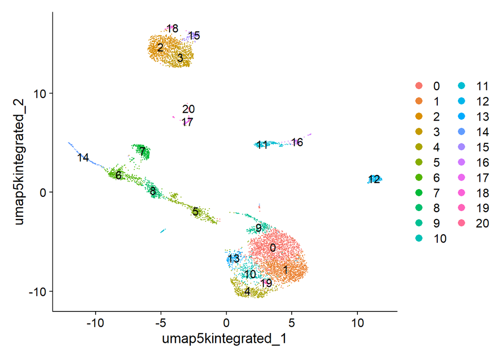

```r
  DimPlot(LN_5k, reduction = "umap.5k.integrated", label=T)
```

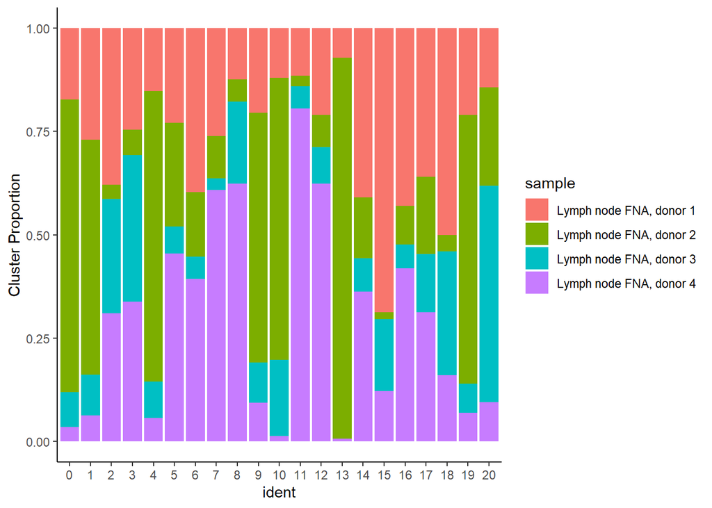

```r
FetchData(LN_5k, c("ident","sample")) %>% group_by(ident) %>%
    mutate(prop=1/length(ident)) %>%
    ungroup() %>%
    group_by(ident,sample) %>%
    summarise(totprop=sum(prop), .groups = "drop") %>%
    ggplot(aes(x=ident,fill=sample,y=totprop)) +
    geom_bar(position='fill', stat='identity') +
    theme(axis.text.x =element_text(angle = 45,hjust=1))+scale_y_continuous(name="Cluster Proportion")+ theme_classic()
```

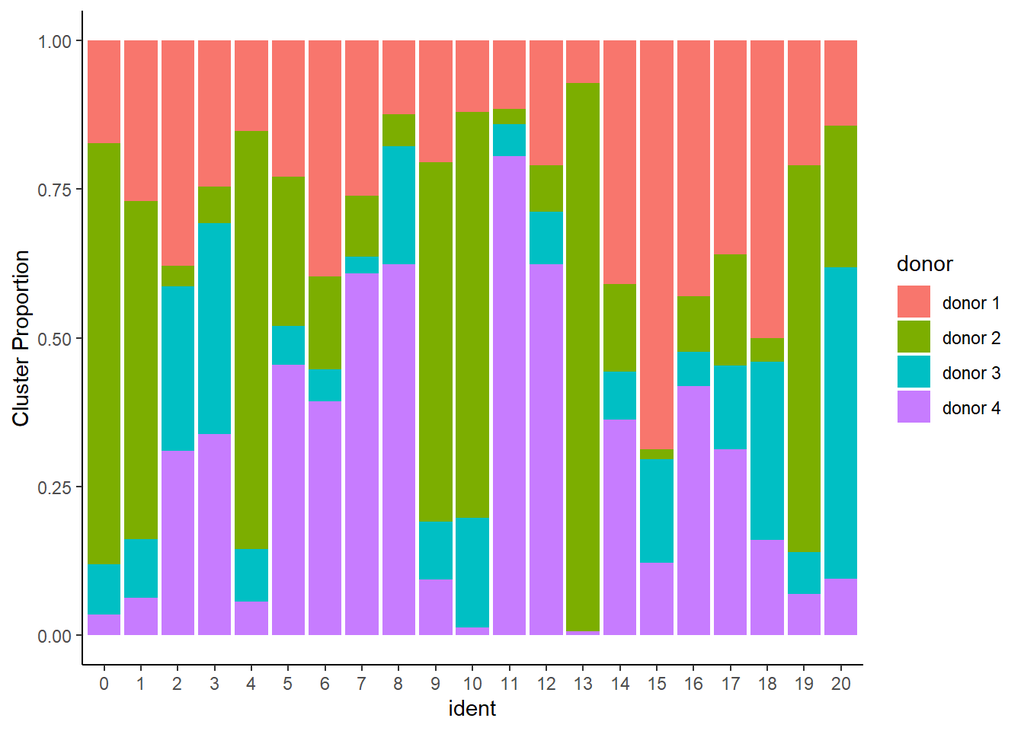

```r
FetchData(LN_5k, c("ident","donor")) %>% group_by(ident) %>%
    mutate(prop=1/length(ident)) %>%
    ungroup() %>%
    group_by(ident,donor) %>%
    summarise(totprop=sum(prop),.groups = "drop") %>%
    ggplot(aes(x=ident,fill=donor,y=totprop)) +
    geom_bar(position='fill', stat='identity') +
    theme(axis.text.x =element_text(angle = 45,hjust=1))+scale_y_continuous(name="Cluster Proportion")+ theme_classic()
```

# Use Dotplot to visualize gene expression, and annotate clusters note: always set default assay to ‘RNA’ when looking at gene expression From the UMAP we can see the current resolution can’t seperate cDC1 and cDC2, needs to be improved later

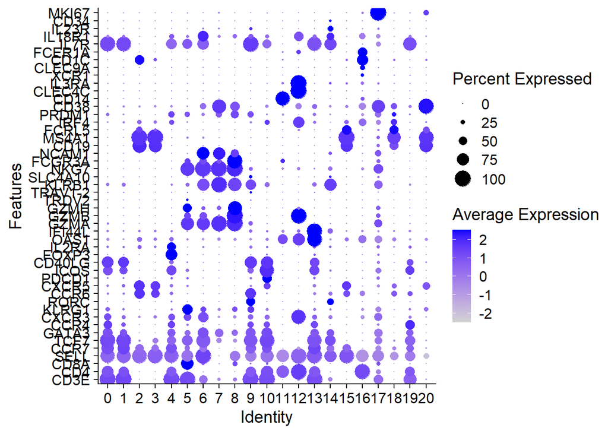

```r
DefaultAssay(LN_5k) <- "RNA"
Markers <- c('CD3E','CD4','CD8A','SELL','CCR7','TCF7','GATA3','CCR4','CXCR3','KLRG1','RORC','CCR6','CXCR5','PDCD1','ICOS','CD40LG','FOXP3','IL2RA','OAS1','ISG15','IFI44L','GZMA','GZMB','GZMH','GZMM','TRDV2','TRAV1-2','KLRB1','SLC4A10','NKG7','FCGR3A','NCAM1','CD19','MS4A1','IGHM','FCRL5','IRF4','PRDM1','CD38','CST3','LYZ','CD14','CLEC4C','IL3RA','XCR1','CLEC9A','CD1C','FCER1A','IL7R','IL18R1','IL23R','CD34','MKI67')
DotPlot(LN_5k, features = Markers) +coord_flip()
```

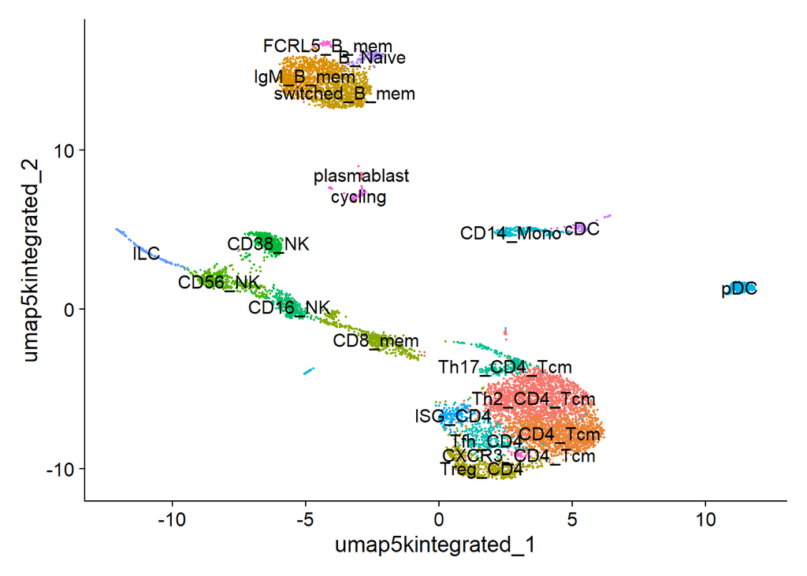

```r
new.cluster.ids <- c(`0` = "Th2_CD4_Tcm",
                     `1` = "CD4_Tcm",
                     `2` = "IgM_B_mem",
                     `3` = "switched_B_mem",
                     `4` = "Treg_CD4",
                     `5` = "CD8_mem",
                     `6` = "CD56_NK",
                     `7` = "CD38_NK",
                     `8` = "CD16_NK",
                     `9` = "Th17_CD4_Tcm",
                     `10` = "Tfh_CD4",
                     `11` = "CD14_Mono",
                     `12` = "pDC",
                     `13` = "ISG_CD4",
                     `14` = "ILC",
                     `15` = "B_Naive",
                     `16` = "cDC",
                     `17` = "cycling",
                     `18` = "FCRL5_B_mem",
                     `19` = "CXCR3_CD4_Tcm",
                     `20` = "plasmablast"
                     )
names(new.cluster.ids) <- levels(LN_5k)
LN_5k <- RenameIdents(LN_5k, new.cluster.ids)
DimPlot(LN_5k, reduction = "umap.5k.integrated", label = TRUE, pt.size = 0.3) + NoLegend()
```

# Visualize inflammasome genes This doesn’t make sense without comparison though.

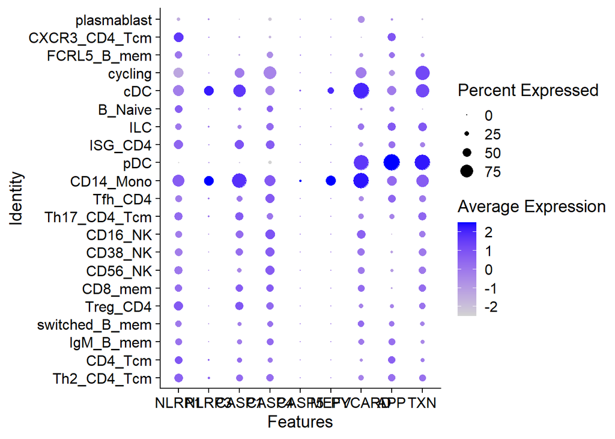

```r
inflammasome_genes <- c("NLRP1","NLRP3","CASP1","CASP4","CASP5","MEFV","PYCARD","APP","TXN")
DotPlot(LN_5k, features = inflammasome_genes)
```

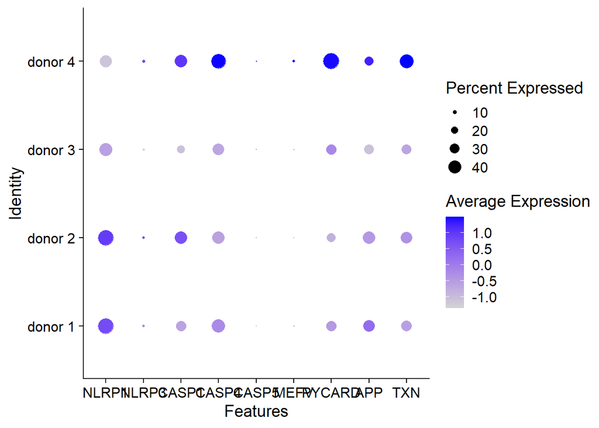

```r
DotPlot(LN_5k, features = inflammasome_genes, group.by = "donor")
```

**From the umap we can see we lost 10 clusters by subsetting genes, next step will try annotating clusters using reference datasets or online tool**